# Week 3 Notes Part 2 Extensions Beyond Linear Models

# 1 Overview

In Part 1 of this week’s Notes we established the linear model as our core tool for characterizing a relationship between a continuous predictor and a continuous response, and we spent considerable effort making sure that we know how to fit such a model, interpret its coefficients, and check whether its underlying assumptions actually hold for the data at hand. A natural question follows immediately from that last point: what are we supposed to do when the diagnostic plots tell us that a straight line is not, in fact, a good description of the relationship we are looking at? This is precisely the question this Note addresses.

We are going to look at three different families of methods for handling this situation, and it is useful to think of them as ordered along a single axis: how much do we have to assume, in advance, about the shape of the relationship we are trying to describe? At one extreme we have the Emax dose-response model, a specific nonlinear equation borrowed from pharmacology that is useful precisely when we already know, from the biology of the problem, what shape the relationship ought to take. At the other extreme we have LOESS and spline smoothing, which make essentially no assumption at all about the functional form and simply let the data speak for themselves, at the cost of not handing us back an equation we can write down and interpret. In between sit Generalized Additive Models, or GAMs, which retain much of the interpretability and formal significance testing we grew accustomed to with linear models, while still allowing each predictor’s effect to take whatever smooth shape the data actually suggest. As we did in Part 1, we will develop all three approaches hands-on, using the same ALL dataset gene expression and days-to-remission variables we have already been working with this week, so that at every step we can compare the new method directly against the linear fit we already have in hand.

# 2 Why Dose-Response Relationships Are Not Linear

Let us begin with a concrete example, since the Emax model we are about to introduce is easiest to motivate from a specific biological scenario rather than from abstract principles alone. Suppose we are measuring the effect of a drug, a reduction in some biomarker level, say, or the percent inhibition of a target enzyme, across a range of doses administered to different subjects or cultures. At very low doses we should not expect to see much of an effect at all: there is simply not enough drug present to engage the target in any meaningful way. As the dose increases, the effect typically rises, often quite steeply over some range, and then it saturates: past some point, giving still more drug produces very little additional benefit, because the target it acts on, a receptor or an enzyme, is already close to maximally engaged. Plotted against the logarithm of dose, this produces a characteristic S-shaped, or sigmoidal, curve, and not a straight line.

If we were to fit a linear model to data of this kind anyway, using exactly the machinery from Part 1, we would end up with a poor description of the relationship in two distinct ways: the fitted line would keep predicting ever-larger effects at high doses, when in reality the effect has already leveled off, and at the same time it would fail to capture the threshold-like flatness we expect to see at low doses. Neither failure would necessarily announce itself through the p-value alone, since a strong overall trend can still produce a very small p-value even when the functional form fitted is the wrong one, which is exactly why we spent so much of Part 1 on diagnostic plots rather than significance in isolation.

# 3 The Emax Model

The most commonly used parametric model for a relationship of this shape is the sigmoidal Emax model:

**(1)**

$$E(D) = E_0 + \frac{E_{max} \cdot
D^h}{ED_{50}^h + D^h}$$

Here $E(D)$ is the effect predicted by the model at dose $D$, and the model carries four parameters, each with a direct pharmacological meaning attached to it, which is precisely what makes this model so attractive whenever it applies. $E_0$ is the baseline effect we would observe even at zero dose, the background level we have already had occasion to discuss in earlier Notes. $E_{max}$ is the maximum additional effect the drug can produce above that baseline as the dose grows without bound, and it is exactly the quantity we have in mind whenever we ask how much effect a drug has above background. $ED_{50}$ is the dose at which the effect reaches exactly half of $E_{max}$, and it serves as our measure of potency: the smaller $ED_{50}$ is, the less drug is needed to reach half of the maximal effect, so a smaller $ED_{50}$ corresponds to a more potent drug. Finally, $h$, the Hill coefficient, governs how steeply the curve rises from no effect to maximal effect; larger values of $h$ produce a sharper, more switch-like transition between the two.

Because the dose $D$ enters this expression nonlinearly, raised to a power, and appearing in the denominator as well as the numerator, we cannot fit this model the way we fitted the models of Part 1, by solving a system of linear equations for the unknown coefficients. Instead we have to turn to nonlinear least squares.

# 4 Fitting an Emax Model in R

R’s base `nls()` function (nonlinear least squares) fits models of exactly this form, provided we can supply it with a reasonable starting guess for the parameters. Let us simulate a simple dose-response dataset in order to illustrate the fitting process; a real pharmacology assay would of course supply the data rather than a simulation, but the fitting procedure itself does not care where the numbers came from:

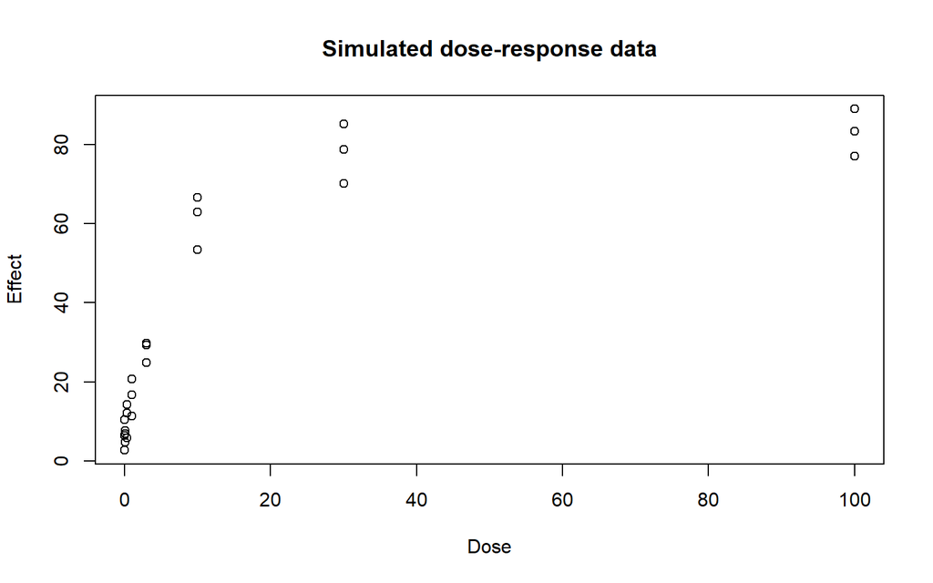

```r
set.seed(42)
dose <- rep(c(0, 0.1, 0.3, 1, 3, 10, 30, 100), each=3)  # triplicate measurements per dose
E0.true <- 5; Emax.true <- 80; ED50.true <- 5; h.true <- 1.5
mean.effect <- E0.true + (Emax.true * dose^h.true) / (ED50.true^h.true + dose^h.true)
effect <- mean.effect + rnorm(length(dose), sd=4)  # add measurement noise
dr.df <- data.frame(dose=dose, effect=effect)
plot(dose, effect, xlab="Dose", ylab="Effect", main="Simulated dose-response data")
```

Plotted against dose on a linear scale, as we just did, the sigmoidal shape is compressed into the left-hand edge of the plot and is difficult to see clearly. It is conventional, therefore, to plot dose-response data against the logarithm of dose instead (after first replacing any dose of exactly 0 with a small placeholder value, since the logarithm of zero is not defined):

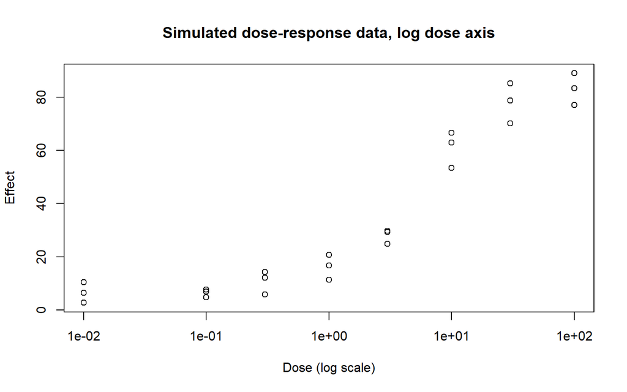

```r
dose.plot <- ifelse(dose==0, 0.01, dose)  # placeholder for log-scale plotting only
plot(dose.plot, effect, log="x", xlab="Dose (log scale)", ylab="Effect",
     main="Simulated dose-response data, log dose axis")
```

Now let us actually fit the Emax model using `nls()`. Nonlinear fitting requires a reasonable starting value for every parameter, since, unlike `lm()`, there is no closed-form solution for the optimum; the algorithm instead searches iteratively from wherever we tell it to start, and a poor starting guess can cause the search to fail to converge, or to converge to the wrong local optimum entirely:

```r
emax.fit <- nls(effect ~ E0 + (Emax * dose^h) / (ED50^h + dose^h),
                 data=dr.df,
                 start=list(E0=0, Emax=70, ED50=5, h=1))
summary(emax.fit)
```

```
##
## Formula: effect ~ E0 + (Emax * dose^h)/(ED50^h + dose^h)
##
## Parameters:
##      Estimate Std. Error t value Pr(>|t|)
## E0     7.7428     1.7009   4.552 0.000194 ***
## Emax  77.3256     3.8652  20.005 1.07e-14 ***
## ED50   5.8218     0.7082   8.221 7.64e-08 ***
## h      1.3802     0.1946   7.093 7.10e-07 ***
## ---
## Signif. codes:  0 '***' 0.001 '**' 0.01 '*' 0.05 '.' 0.1 ' ' 1
##
## Residual standard error: 4.799 on 20 degrees of freedom
##
## Number of iterations to convergence: 7
## Achieved convergence tolerance: 4.414e-06
```

The fitted coefficients give us our estimates of $E_0$, $E_{max}$, $ED_{50}$, and $h$ from the data alone. It is worth comparing them against the true values we used to simulate the data in the first place; because we deliberately added measurement noise, the fitted values approximate but do not exactly reproduce the generating parameters, which is exactly what we should expect from any fitting procedure applied to noisy data, whether linear or not. We can overlay the fitted curve on top of the observed points to see how well it tracks the data:

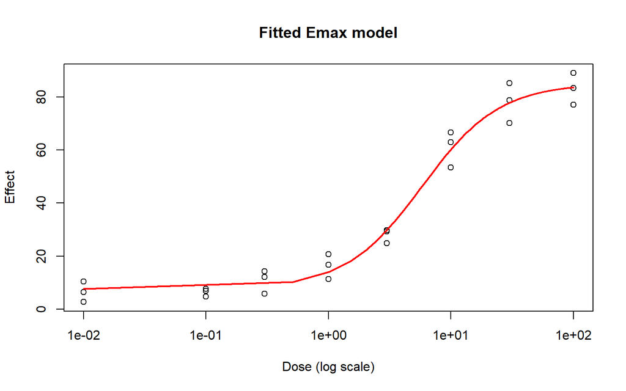

```r
dose.seq <- seq(0.01, 100, length.out=200)
pred.effect <- predict(emax.fit, newdata=data.frame(dose=dose.seq))
plot(dose.plot, effect, log="x", xlab="Dose (log scale)", ylab="Effect",
     main="Fitted Emax model")
lines(dose.seq, pred.effect, col="red", lwd=2)
```

# 5 Interpreting Emax in the Context of “Effect Above Background”

The Emax model gives us a direct, interpretable answer to the question of how a drug’s effect compares to background levels: $E_0$ *is* the background level, the response we would observe with no drug present at all, and $E_{max}$ is, by the very construction of the model, the maximum effect the drug can add above that background, at any dose whatsoever. This is a considerably more complete characterization of the relationship than a single treatment-versus-control comparison, of the kind we would get from a t-test or an ANOVA, because it describes the entire dose-response curve rather than the effect observed at just one tested dose, which turns out to be useful for choosing doses in follow-up studies, among other purposes.

It is also worth pointing out the connection back to the linear models and diagnostics we covered earlier this week. The same residual diagnostics we introduced for `lm()` objects, checking that the residuals are reasonably homoscedastic and approximately normally distributed, remain just as relevant for a nonlinear fit like this one, and `nls()` objects support `residuals()` and `fitted()` for exactly this purpose, in the same way `lm()` objects do.

# 6 A Note on Model Selection

Not every apparently curved relationship calls for an Emax model specifically. The polynomial regression we already practiced in Part 1, together with the splines and LOESS smoothing we are about to cover in this Note, are simpler and more flexible alternatives, and they are the right choice whenever the underlying biological mechanism does not itself suggest a specific sigmoidal saturation process. The Emax model earns its place specifically in pharmacological contexts because its four parameters map onto quantities with direct scientific meaning and regulatory relevance; a polynomial or spline fit might describe the same data just as well in a purely numerical sense, but it will not hand us parameters we can interpret in the same way.

# 7 The Problem: When Linear Models Fit Poorly

Before introducing the remaining alternatives, let us establish precisely when a linear model is the wrong tool for the job in the first place. The diagnostic plots we developed in Part 1 are the first and most direct signal: specifically, a curved pattern in the residuals-versus-fitted plot indicates a systematic nonlinearity that the linear model is failing to capture.

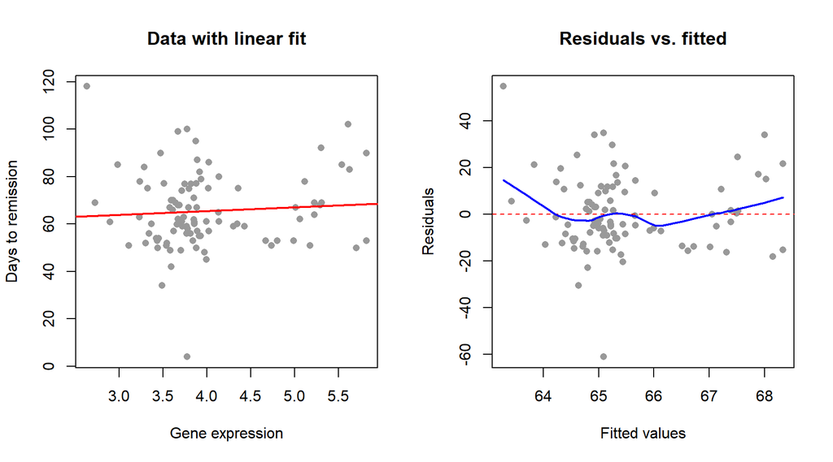

```r
library(ALL); data(ALL)
# Reconstruct the days-to-remission variable used throughout this week:
ALL.pdat    <- pData(ALL)
date.cr.chr <- as.character(ALL.pdat$date.cr)
diag.chr    <- as.character(ALL.pdat$diagnosis)
date.cr.t   <- strptime(date.cr.chr, "%m/%d/%Y")
diag.t      <- strptime(diag.chr,    "%m/%d/%Y")
days2remiss <- as.numeric(date.cr.t - diag.t)
# Select a gene for illustration:
gene.names <- rownames(exprs(ALL))
G <- exprs(ALL)[gene.names[50], ]
df.week3 <- data.frame(G=G, D2R=as.numeric(days2remiss))
df.week3 <- df.week3[!is.na(df.week3$D2R), ]
# Fit a linear model and examine the diagnostic residuals vs. fitted plot:
lm.fit <- lm(D2R ~ G, data=df.week3)
par(mfrow=c(1,2))
plot(df.week3$G, df.week3$D2R,
     xlab="Gene expression", ylab="Days to remission",
     main="Data with linear fit", pch=16, col="gray60")
abline(lm.fit, col="red", lwd=2)
plot(fitted(lm.fit), residuals(lm.fit),
     xlab="Fitted values", ylab="Residuals",
     main="Residuals vs. fitted", pch=16, col="gray60")
abline(h=0, lty=2, col="red")
lines(lowess(fitted(lm.fit), residuals(lm.fit)), col="blue", lwd=2)
```

```r
par(mfrow=c(1,1))
```

The blue line drawn through the residuals-versus-fitted plot is itself a LOESS smooth, the very technique we are about to introduce properly; R’s `plot.lm()` adds a line of this kind automatically, which is a small preview of just how useful this smoothing idea turns out to be. If this blue line departs substantially from zero, tracing out a visible curve rather than hugging the horizontal reference line, the linear model is missing something. Whether the particular gene selected here shows strong nonlinearity or not depends on which gene we happened to pick, but the diagnostic workflow itself, look for curvature in the residuals, is exactly the same regardless of which predictor we are examining.

# 8 LOESS: Locally Weighted Scatterplot Smoothing

## 8.1 The Core Idea

LOESS, also written LOWESS, for Locally Weighted Scatterplot Smoothing, fits a smooth curve to bivariate data without assuming any particular functional form for that curve at all. Rather than fitting one global line through the entire dataset, the way `lm()` does, LOESS fits a separate, local polynomial regression at each point $x_0$ in the data, using only the points near $x_0$, weighted according to how close they are to it. Points close to $x_0$ receive a large weight in that local fit; points farther away receive a small weight, or none at all.

Formally, at each target point $x_0$, LOESS solves a weighted least squares problem of the form

$$\hat{f}(x_0) = \arg\min_{\beta}
\sum_{i=1}^n w_i(x_0) \left(y_i - \beta_0 - \beta_1(x_i - x_0) - \ldots
\right)^2$$

where $w_i(x_0)$ is a weight function, typically a tri-cube kernel, that falls to zero outside some neighborhood of $x_0$. The fitted value at $x_0$ is then simply $\hat{\beta}_0$ from this one local fit, and repeating the same calculation at every $x_0$ across the range of the data traces out the smooth curve we actually see plotted.

## 8.2 The Bandwidth (span) Parameter

The key tuning parameter governing this whole procedure is what R calls the span, sometimes also called the bandwidth, or $\alpha$: the fraction of the total data points that are allowed to enter into each local fit. A larger span produces a smoother curve, since more data points are averaged into every local estimate, washing out local variation; a smaller span produces a more wiggly curve that tracks local features of the data much more closely, at some risk of tracking noise rather than signal. Let us see this directly, by fitting the same data with three different spans side by side:

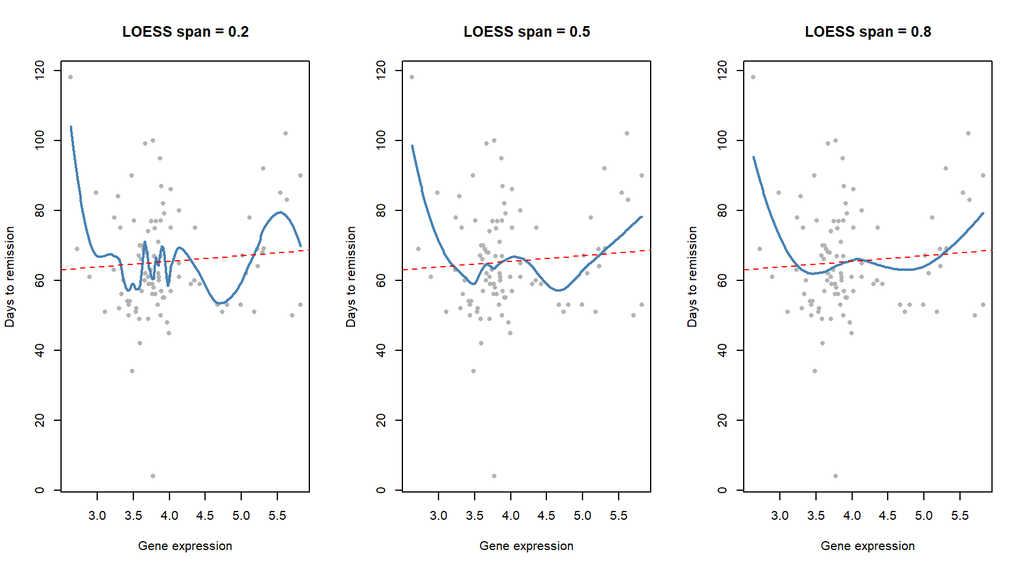

```r
# Demonstrate the effect of span on LOESS smoothness:
par(mfrow=c(1,3))
for (sp in c(0.2, 0.5, 0.8)) {
  plot(df.week3$G, df.week3$D2R,
       xlab="Gene expression", ylab="Days to remission",
       main=paste0("LOESS span = ", sp),
       pch=16, col="gray70", cex=0.8)
  loess.fit <- loess(D2R ~ G, data=df.week3, span=sp)
  # Create a sequence for smooth prediction:
  g.seq <- seq(min(df.week3$G), max(df.week3$G), length.out=200)
  pred  <- predict(loess.fit, newdata=data.frame(G=g.seq))
  lines(g.seq, pred, col="steelblue", lwd=2)
  abline(lm.fit, col="red", lwd=1, lty=2)
}
```

```r
par(mfrow=c(1,1))
```

## 8.3 LOESS in Practice: Visualization and Residual Diagnostics

LOESS earns its keep in two distinct roles. First, it serves as a visualization tool: plotting a LOESS smooth over raw data lets us see the shape of a relationship before we commit to any particular parametric model. Second, it serves as a diagnostic tool, which we have in fact already used once above: a LOESS smooth laid over a residual plot reveals whether a parametric model’s assumptions are actually being met.

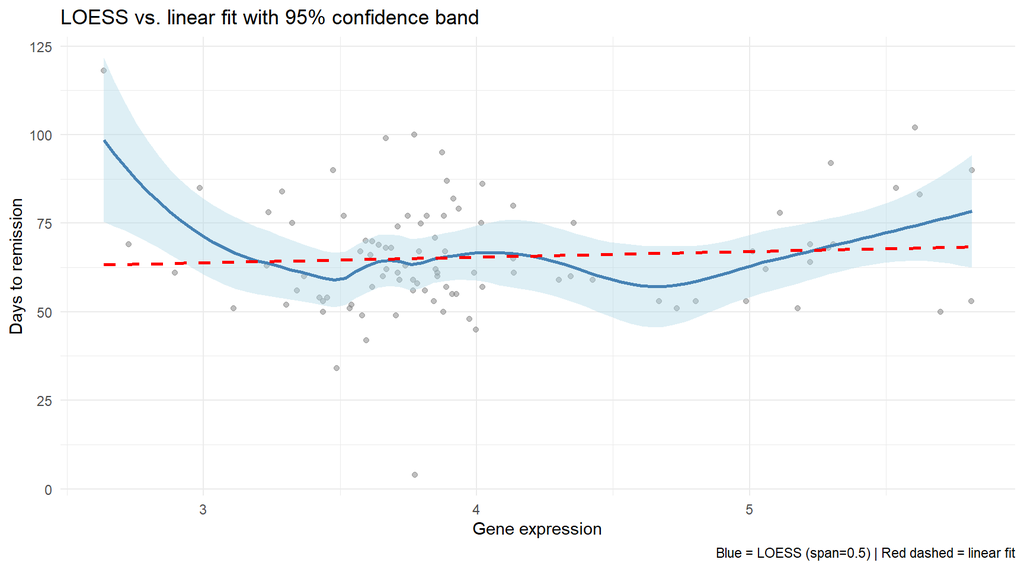

```r
library(ggplot2)
# ggplot's geom_smooth() uses LOESS by default for n < 1000:
ggplot(df.week3, aes(x=G, y=D2R)) +
  geom_point(alpha=0.5, color="gray50") +
  geom_smooth(method="loess", span=0.5, se=TRUE,
              color="steelblue", fill="lightblue") +
  geom_smooth(method="lm", se=FALSE, color="red", linetype="dashed") +
  labs(title="LOESS vs. linear fit with 95% confidence band",
       x="Gene expression", y="Days to remission",
       caption="Blue = LOESS (span=0.5) | Red dashed = linear fit") +
  theme_minimal()
```

The shaded band drawn around the LOESS curve is estimated by `ggplot` from point-wise standard errors, and it gives us a visual sense of how uncertain the smooth is at each point along the range of the data (naturally, the band tends to widen wherever the data are sparse). Wherever the linear fit, shown in red, falls outside this confidence band, we have evidence that the linear model is a poor approximation to the true relationship at that point. Wherever the two curves largely agree, on the other hand, the linear model is a perfectly reasonable simplification, and there is little to be gained from anything more elaborate.

## 8.4 LOESS for Multiple Predictors

LOESS can, in principle, be extended to handle more than one predictor at a time, but it becomes computationally impractical once we go beyond two, a consequence of what is sometimes called the curse of dimensionality: with many predictors, any given point in the data simply does not have enough nearby neighbors left to form a sensible local fit. This limitation is precisely what motivates the Generalized Additive Models we turn to shortly, once we have covered splines, the mathematical piece those models are built from.

## 8.5 LOESS Strengths and Limitations

Like any method, LOESS comes with real strengths as well as real limitations, and it is worth being explicit about both before we move on. On the side of its strengths: it requires no assumption whatsoever about the functional form of the relationship, since the data alone determine the shape of the fit; it is an excellent tool for visualization and for diagnostics of the kind we practiced above; it is readily available in base R through `loess()`, in ggplot2 through `geom_smooth()`, and indeed in virtually every serious plotting library; and the confidence band it produces is a natural output that makes the uncertainty of the fit directly visible rather than something we have to compute separately.

Against these strengths, LOESS also has real limitations that keep it from being a complete replacement for a parametric model. It does not produce interpretable coefficients: we cannot say that a one-unit increase in $X$ is associated with some fixed change in the response, because the relationship is allowed to change shape across the range of $X$. It does not generalize to non-Gaussian outcomes without further modification. It cannot sensibly handle many predictors simultaneously, as we have just discussed. Predictions near the extremes of the observed data range can be unreliable, a boundary effect that arises because there are fewer neighboring points available to inform the local fit out there. And, perhaps most importantly for our purposes in this course, it is not well suited to formal inference, meaning hypothesis testing, on its own.

# 9 Splines: The Mathematical Foundation of Smooth Functions

Before we can properly introduce GAMs, it helps to understand splines, since splines are the mathematical building block GAMs use internally to represent smooth, nonlinear functions.

A spline is a piecewise polynomial function that is joined smoothly at a set of points called knots. A cubic spline, for instance, fits a separate cubic polynomial between each pair of adjacent knots, subject to the constraint that the individual pieces join up smoothly with each other, meaning that their values, first derivatives, and second derivatives all match at every knot. The result is a single smooth, flexible curve that is nonetheless built out of many simple polynomial pieces, and that can follow considerably more complex patterns in the data than any single low-order polynomial could on its own.

The key insight to take away is this: any reasonably smooth function over an interval can be well approximated by a spline, provided we allow ourselves enough knots. GAMs exploit exactly this fact: they represent each predictor’s effect as a spline function and then fit all of the splines simultaneously, within a penalized regression framework that keeps the fitted curves from becoming needlessly wiggly.

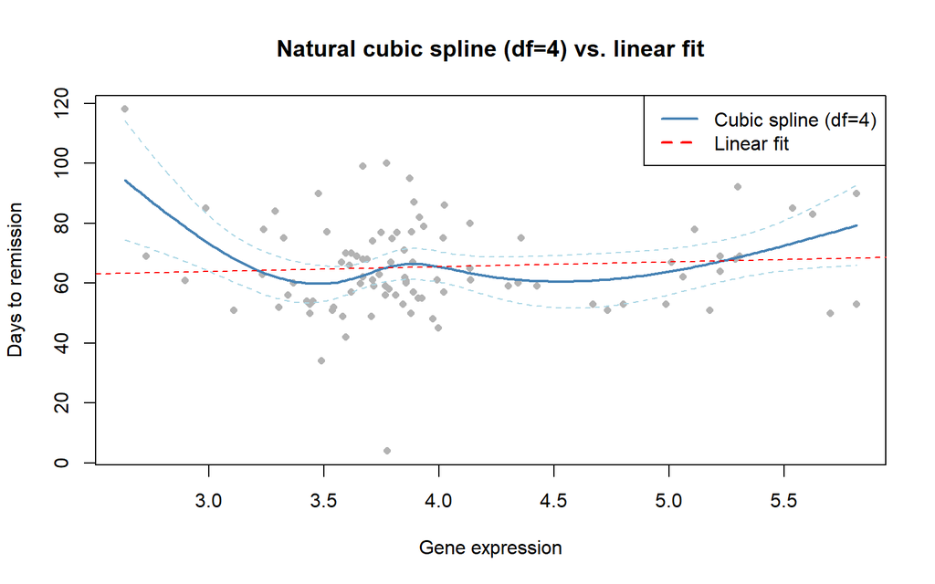

```r
library(splines)
# Fit a natural cubic spline regression with 4 degrees of freedom:
# (equivalent to 3 interior knots placed at quantiles of G)
spline.fit <- lm(D2R ~ ns(G, df=4), data=df.week3)
g.seq <- seq(min(df.week3$G), max(df.week3$G), length.out=200)
spline.pred <- predict(spline.fit,
                       newdata=data.frame(G=g.seq),
                       interval="confidence")
plot(df.week3$G, df.week3$D2R,
     xlab="Gene expression", ylab="Days to remission",
     main="Natural cubic spline (df=4) vs. linear fit",
     pch=16, col="gray70", cex=0.8)
lines(g.seq, spline.pred[,"fit"],  col="steelblue", lwd=2)
lines(g.seq, spline.pred[,"lwr"],  col="lightblue", lwd=1, lty=2)
lines(g.seq, spline.pred[,"upr"],  col="lightblue", lwd=1, lty=2)
abline(lm.fit, col="red", lwd=1, lty=2)
legend("topright", c("Cubic spline (df=4)", "Linear fit"),
       col=c("steelblue","red"), lwd=2, lty=c(1,2))
```

Notice that the spline fit above was obtained with `lm()`, the very same function we used throughout Part 1, simply given a more elaborate formula. This is worth pausing on: `ns(G, df=4)` expands the single predictor $G$ into several new derived columns representing the spline basis, and `lm()` then fits ordinary linear coefficients against those derived columns, so a spline regression is, from R’s point of view, still a linear model in the sense we discussed at length in Part 1, linear in its parameters, even though it is very much not linear in $G$ itself. This is exactly the same trick we already saw with the quadratic term $X^2$ in Part 1: a new column derived from the original predictor, fitted with ordinary linear coefficients. The cubic spline shown here can follow curves that a straight line simply cannot, while still remaining a regression model that produces the confidence intervals and significance tests we already know how to interpret. The `df` argument, degrees of freedom, controls how flexible the fit is allowed to be: `df=2` reduces to an ordinary linear fit, and larger values allow progressively more wiggle. GAMs, which we turn to next, essentially automate the process of choosing this smoothness for us, rather than requiring us to pick `df` by hand.

# 10 Generalized Additive Models (GAMs)

## 10.1 From Linear Models to GAMs

Recall the linear model from Part 1, extended here to several predictors at once:

$$E[Y | X_1, \ldots, X_p] = \beta_0 +
\beta_1 X_1 + \ldots + \beta_p X_p$$

A GAM relaxes the linearity constraint on the right-hand side of this equation by replacing each term $\beta_j X_j$ with a smooth function $f_j(X_j)$ instead:

$$E[Y | X_1, \ldots, X_p] = \beta_0 +
f_1(X_1) + f_2(X_2) + \ldots + f_p(X_p)$$

Each $f_j$ is estimated directly from the data, as a smooth spline function of the kind we just introduced, without our having to pre-specify its shape in advance. The word “additive” in the name refers to the fact that the individual predictors’ effects still simply add together, exactly as they did in the linear model; what has changed is only that each predictor is now permitted to contribute a curve rather than a straight line. This additive structure is precisely what keeps GAMs so much more interpretable than a fully nonlinear black-box model, such as a random forest: we can still plot and interpret the effect of each predictor separately, one at a time, in a way that a black-box model simply will not allow. Like the generalized linear models we will cover in Week 5, GAMs can also handle non-Gaussian outcomes through a link function, so a GAM can be fit for a binary outcome (a logistic GAM) or a count outcome (a Poisson GAM), among other possibilities.

## 10.2 Fitting a GAM in R

The `mgcv` package supplies the `gam()` function for this purpose. Smooth terms are specified with `s()` inside the model formula, and the package automatically chooses how smooth each term should be, using penalized regression, specifically either generalized cross-validation or REML, so that we are spared from having to pick a `df` by hand the way we did for the spline above:

```r
library(mgcv)
# Fit a GAM with a smooth term for gene expression:
gam.fit <- gam(D2R ~ s(G), data=df.week3, method="REML")
summary(gam.fit)
```

```
##
## Family: gaussian
## Link function: identity
##
## Formula:
## D2R ~ s(G)
##
## Parametric coefficients:
##             Estimate Std. Error t value Pr(>|t|)
## (Intercept)   65.456      1.585   41.29   <2e-16 ***
## ---
## Signif. codes:  0 '***' 0.001 '**' 0.01 '*' 0.05 '.' 0.1 ' ' 1
##
## Approximate significance of smooth terms:
##        edf Ref.df     F p-value
## s(G) 2.946  3.694 1.751   0.138
##
## R-sq.(adj) =  0.0644   Deviance explained = 9.34%
## -REML = 397.57  Scale est. = 241.22    n = 96
```

The summary output is organized into two parts. The parametric coefficients section, which here contains only the intercept, tells us the overall mean of the outcome. The smooth terms section is new and deserves some explanation: it reports the estimated degrees of freedom, or edf, of the smooth, a measure of how wiggly the fitted curve actually turned out to be (an edf of 1 means the smooth has effectively collapsed down to a straight line, while an edf close to the maximum allowed by the basis dimension means a genuinely wiggly fit), together with an F statistic and a p-value testing whether the smooth term differs significantly from zero, in other words whether the predictor has any relationship at all with the outcome.

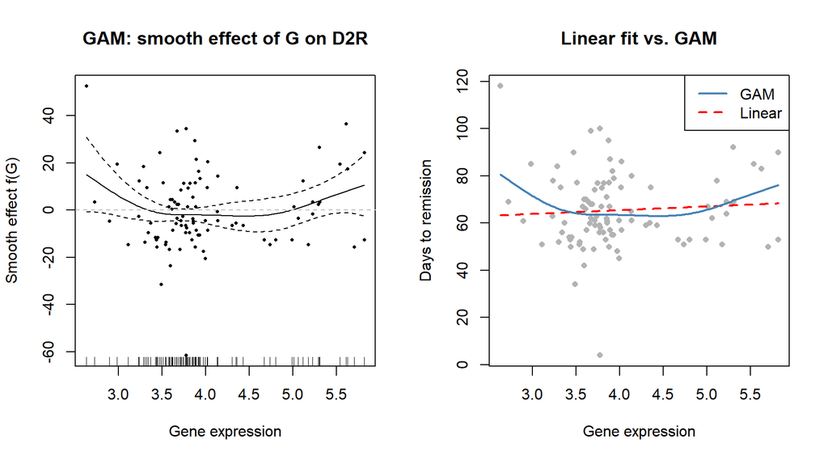

```r
# Plot the GAM smooth with confidence band:
par(mfrow=c(1,2))
plot(gam.fit, residuals=TRUE, pch=16, cex=0.5,
     shade=TRUE, shade.col="lightblue",
     xlab="Gene expression",
     ylab="Smooth effect f(G)",
     main="GAM: smooth effect of G on D2R")
abline(h=0, lty=2, col="gray")
# Compare fitted values: linear vs. GAM:
g.seq <- seq(min(df.week3$G), max(df.week3$G), length.out=200)
pred.lm  <- predict(lm.fit,  newdata=data.frame(G=g.seq))
pred.gam <- predict(gam.fit, newdata=data.frame(G=g.seq))
plot(df.week3$G, df.week3$D2R,
     pch=16, col="gray70", cex=0.8,
     xlab="Gene expression", ylab="Days to remission",
     main="Linear fit vs. GAM")
lines(g.seq, pred.lm,  col="red",      lwd=2, lty=2)
lines(g.seq, pred.gam, col="steelblue", lwd=2)
legend("topright", c("GAM", "Linear"),
       col=c("steelblue","red"), lwd=2, lty=c(1,2))
```

```r
par(mfrow=c(1,1))
```

## 10.3 GAMs with Multiple Predictors

The real advantage of GAMs over LOESS becomes apparent once we move to multiple predictors. Each predictor is given its own smooth term, and all of the smooths are estimated jointly, each one controlling for the others, in much the same spirit as multiple linear regression:

```r
# Build a dataset with two gene predictors:
G2 <- exprs(ALL)[gene.names[200], ]
df.two <- data.frame(G1=G, G2=G2, D2R=as.numeric(days2remiss))
df.two <- df.two[!is.na(df.two$D2R), ]
# Fit a GAM with smooth terms for both genes:
gam.two <- gam(D2R ~ s(G1) + s(G2), data=df.two, method="REML")
summary(gam.two)
```

```
##
## Family: gaussian
## Link function: identity
##
## Formula:
## D2R ~ s(G1) + s(G2)
##
## Parametric coefficients:
##             Estimate Std. Error t value Pr(>|t|)
## (Intercept)   65.456      1.564   41.85   <2e-16 ***
## ---
## Signif. codes:  0 '***' 0.001 '**' 0.01 '*' 0.05 '.' 0.1 ' ' 1
##
## Approximate significance of smooth terms:
##         edf Ref.df     F p-value
## s(G1) 2.897  3.637 2.713  0.0433 *
## s(G2) 1.000  1.000 3.637  0.0597 .
## ---
## Signif. codes:  0 '***' 0.001 '**' 0.01 '*' 0.05 '.' 0.1 ' ' 1
##
## R-sq.(adj) =  0.089   Deviance explained = 12.6%
## -REML = 394.07  Scale est. = 234.87    n = 96
```

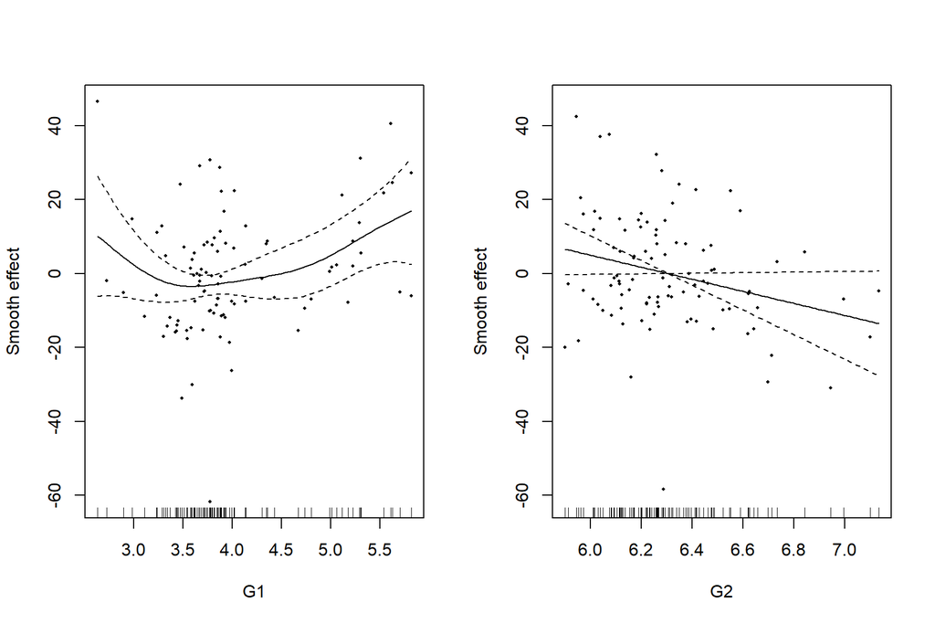

```r
# Plot both smooth terms side by side:
par(mfrow=c(1,2))
plot(gam.two, shade=TRUE, shade.col="lightblue",
     residuals=TRUE, pch=16, cex=0.4, pages=0,
     ylab="Smooth effect")
```

```r
par(mfrow=c(1,1))
```

Each smooth term above is estimated while the other predictor is held at its mean value, exactly the same “controlling for” logic we would invoke for a coefficient in a multiple linear regression, except that here each effect is allowed to be a curve rather than a fixed slope. The p-value attached to each smooth term tests whether that predictor still contributes significantly to the model once the other predictor has already been accounted for.

## 10.4 Interaction Smooths

GAMs can also represent an interaction between two predictors, meaning a relationship where the effect of one predictor changes depending on the value of the other, using tensor product smooths, `te()`, or isotropic smooths, `s(X1, X2)`:

```r
# Smooth interaction between two gene predictors:
gam.int <- gam(D2R ~ te(G1, G2), data=df.two, method="REML")
summary(gam.int)
```

```
##
## Family: gaussian
## Link function: identity
##
## Formula:
## D2R ~ te(G1, G2)
##
## Parametric coefficients:
##             Estimate Std. Error t value Pr(>|t|)
## (Intercept)   65.456      1.543   42.43   <2e-16 ***
## ---
## Signif. codes:  0 '***' 0.001 '**' 0.01 '*' 0.05 '.' 0.1 ' ' 1
##
## Approximate significance of smooth terms:
##             edf Ref.df     F p-value
## te(G1,G2) 5.323  6.169 2.328  0.0398 *
## ---
## Signif. codes:  0 '***' 0.001 '**' 0.01 '*' 0.05 '.' 0.1 ' ' 1
##
## R-sq.(adj) =  0.114   Deviance explained = 16.4%
## -REML = 384.55  Scale est. = 228.42    n = 96
```

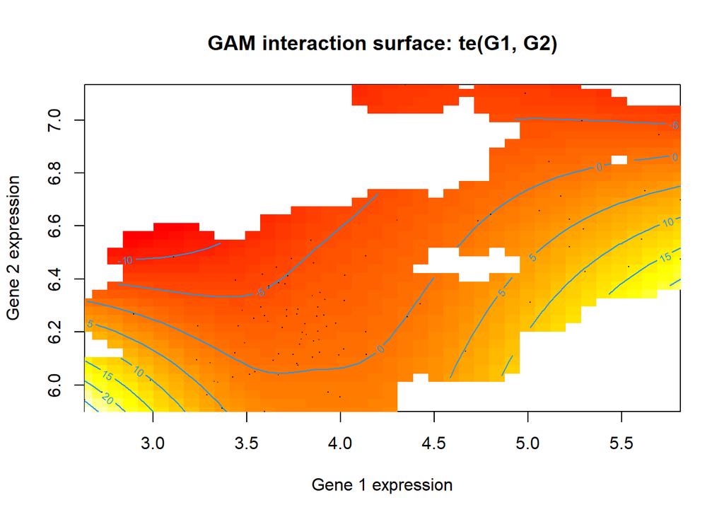

```r
# Visualize the interaction as a surface:
plot(gam.int, scheme=2,
     xlab="Gene 1 expression", ylab="Gene 2 expression",
     main="GAM interaction surface: te(G1, G2)")
```

## 10.5 Comparing Model Fits: Linear, GAM, and LOESS

We now have several different fits to the same data sitting in front of us, and it is natural to ask how we should decide among them in a more quantitative way than simply eyeballing the plots. One standard tool for this is the Akaike Information Criterion, or AIC, which we can compute directly for both the linear model and the GAM:

```r
# Model comparison: linear vs. GAM using AIC:
lm.aic  <- AIC(lm.fit)
gam.aic <- AIC(gam.fit)
cat("Linear model AIC:", round(lm.aic, 2), "\n")
```

```
## Linear model AIC: 809.97
```

```r
cat("GAM AIC:         ", round(gam.aic, 2), "\n")
```

```
## GAM AIC:          806.42
```

```r
cat("Delta AIC (linear - GAM):", round(lm.aic - gam.aic, 2), "\n")
```

```
## Delta AIC (linear - GAM): 3.55
```

```r
cat("(Positive delta = GAM fits better; >2 usually considered meaningful)\n\n")
```

```
## (Positive delta = GAM fits better; >2 usually considered meaningful)
```

```r
# Check if GAM smooth is significantly different from linear:
# If edf ≈ 1, the GAM effectively reduces to a linear model:
cat("GAM smooth edf:", round(summary(gam.fit)$s.table[,"edf"], 2), "\n")
```

```
## GAM smooth edf: 2.95
```

```r
cat("(edf close to 1 = linear relationship; higher = more nonlinear)\n")
```

```
## (edf close to 1 = linear relationship; higher = more nonlinear)
```

AIC penalizes model complexity along with goodness of fit, so a lower AIC represents a better balance between the two, rather than simply rewarding whichever model fits the training data most closely. If the GAM’s AIC comes out substantially lower than the linear model’s, conventionally by more than about 2, this is evidence that the nonlinear smooth is capturing genuine structure in the data that the straight line misses. If the two AIC values are close to each other, on the other hand, the simpler linear model is generally preferred, on the same grounds of parsimony we have already invoked elsewhere this week. The edf of the smooth term, reported just above, gives us a second, independent way of checking the same thing: an edf near 1 means the GAM itself has effectively chosen a linear relationship, which is itself a reassuring confirmation that the linear model was adequate for this particular predictor all along.

# 11 Summary: Choosing Among Linear, LOESS, Spline, and GAM

Let us draw these four approaches together and think about when each one is the right choice. The linear model remains fully parametric, its coefficients are directly interpretable as slopes, it extends readily to multiple predictors, and, via the generalized linear model framework we will meet in Week 5, it extends to non-Gaussian outcomes as well; it is the right tool whenever the diagnostic plots show no systematic curvature in the residuals, or whenever the scientific question at hand is specifically about the magnitude of a linear association. LOESS sits at the opposite end of the spectrum: it makes no parametric assumption whatsoever, produces no interpretable coefficients, handles at most one or two predictors before becoming impractical, and does not extend to non-Gaussian outcomes at all; its natural role is visualization, seeing the shape of a relationship before committing to a model, or diagnostic smoothing, as we used it earlier in this Note on the residuals-versus-fitted plot. Spline regression occupies a middle position: it is only partly parametric, its coefficients are only partly interpretable on their own (though the fitted curve itself is fully interpretable visually, and it comes with proper confidence intervals), it extends to multiple predictors additively, and, again via the GLM framework, it extends to non-Gaussian outcomes; it is well suited whenever we expect a smooth shape but do not know its exact functional form in advance, and we still want formal confidence intervals. The GAM, finally, generalizes the spline idea to handle multiple predictors cleanly, each with its own smooth and its own significance test, and it extends naturally to non-Gaussian outcomes through the same link-function machinery as a GLM; it is the right default whenever the diagnostic plots reveal systematic nonlinearity, whenever there are multiple predictors that might each have their own nonlinear effect, and whenever formal significance testing on those effects still matters to us, which in a biomedical context it usually does. The Emax model we opened this Note with belongs in this same picture too, but it is reached for specifically when the functional form is already known from the underlying biology or pharmacology and the fitted parameters carry direct scientific meaning of their own, rather than being chosen simply because the relationship happens to look curved.

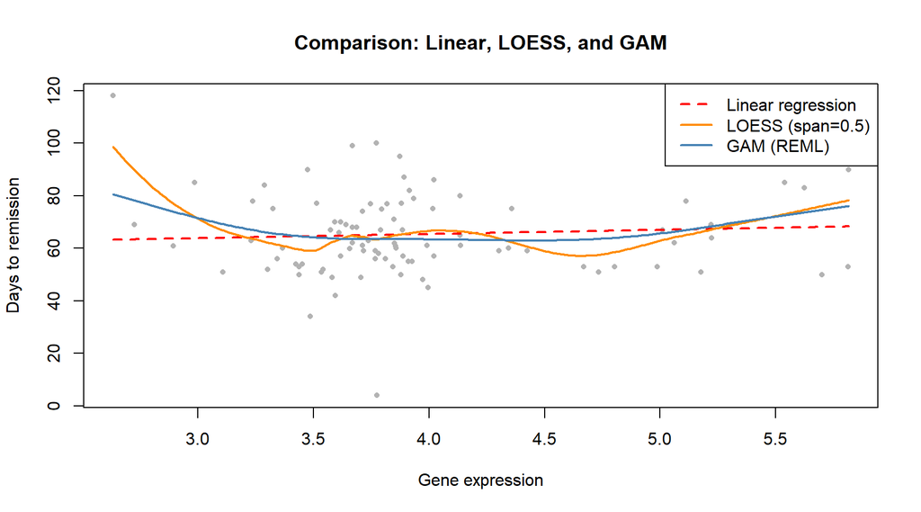

```r
# Full comparison on the same data: linear, LOESS, GAM
g.seq   <- seq(min(df.week3$G), max(df.week3$G), length.out=200)
pred.lm  <- predict(lm.fit,    newdata=data.frame(G=g.seq))
pred.gam <- predict(gam.fit,   newdata=data.frame(G=g.seq))
loess.obj <- loess(D2R ~ G, data=df.week3, span=0.5)
pred.loess <- predict(loess.obj, newdata=data.frame(G=g.seq))
plot(df.week3$G, df.week3$D2R,
     pch=16, col="gray70", cex=0.7,
     xlab="Gene expression", ylab="Days to remission",
     main="Comparison: Linear, LOESS, and GAM")
lines(g.seq, pred.lm,    col="red",       lwd=2, lty=2)
lines(g.seq, pred.loess, col="darkorange", lwd=2)
lines(g.seq, pred.gam,   col="steelblue", lwd=2)
legend("topright",
       c("Linear regression", "LOESS (span=0.5)", "GAM (REML)"),
       col=c("red","darkorange","steelblue"),
       lwd=2, lty=c(2,1,1))
```

When all three curves in a plot like this agree closely with each other, as they may or may not for the particular gene selected here, we have strong evidence that the linear model was adequate all along, and the two nonparametric methods are simply confirming what the straight line already told us rather than contradicting it. When LOESS and the GAM instead diverge substantially from the linear fit, this is a genuine signal of nonlinearity in the underlying relationship, and it is precisely the situation in which reaching for one of the more flexible methods introduced in this Note pays off.